# Untitled

Kuei Yueh Ko

2017年4月25日

# Set Environment

import necessary library

```r
#library(dyplyr)
#library(tidyr)
#library(ggplot2)
library(vegan)
library(MASS)
library(cluster)
library(fpc)
library(proxy)
library(RColorBrewer)

# a bioconductor package for heatmap
#source("https://bioconductor.org/biocLite.R")
#biocLite("ComplexHeatmap")
library(ComplexHeatmap)
# a CRAN package for dendrogram
# install.packages("dendextend")
library(dendextend)
```

setting directories

```r
workdir <- "C:\\Users\\clint\\Documents\\GitHub\\BlogDataAnalysis"
setwd(workdir)

filePathData <- file.path(
    workdir,
    "Data/StatCompEcology/Copepod")
```

# Import data

Read in the copepod data recorded in different stations and preprocess the data to find the dominant species. The final matrix is teh frequency matrix of dominant species in different stations

```r
# intialize a list to store data
datCPOD <- list()

# read tables
dat <- read.table(file.path(
    filePathData, "cop_density.txt"),
    header=T)
datCPOD$Density <- dat

dat <- read.table(file.path(
    filePathData, "copepod_composition.txt"),
    header=T)
datCPOD$Compose <- dat

dat <- read.table(file.path(
    filePathData, "copepodSPlist.txt"),
    sep="\t", header=F)
datCPOD$SP_Total <- as.character(dat$V1)

# Search for dominant species
dat <- datCPOD$Compose
temp <- apply(dat >= 2, 1, sum)
datCPOD$SP_Dominant <- which(temp > 0)

# Extract the composition of dominant species
dat <- datCPOD$Compose
idx <- datCPOD$SP_Dominant
idn <- datCPOD$SP_Total
dat <- dat[idx,]
rownames(dat) <- idn[idx]

# composition of dominant species
# Note: transform the matrix since
# we are clustering on stations
datCPOD$CompDmt <- t(dat)
datCPOD$CompDmtScale <- scale(t(dat)) # scales the columns of a numeric matrix
#head(datCPOD$CompDmtScale)
```

Visualize the data

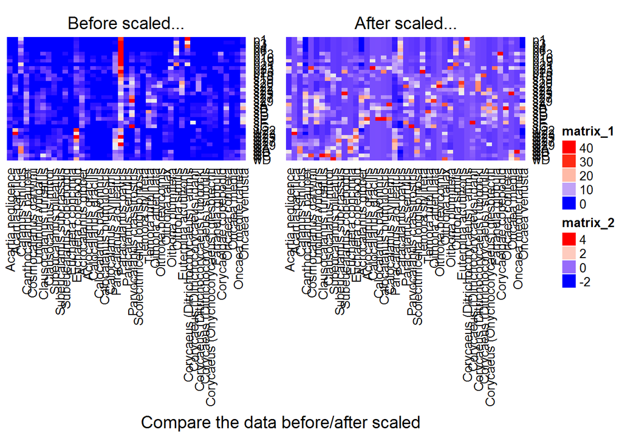

```r
dat <- datCPOD$CompDmt
ht1 <- Heatmap(
    dat, column_title = "Before scaled...",
    row_names_gp = gpar(fontsize = 10),
    column_names_max_height=unit(15, "cm"),
    column_names_gp = gpar(fontsize = 10),
    cluster_rows=F, cluster_columns=F)

dat <- datCPOD$CompDmtScale
ht2 <- Heatmap(
    dat, column_title = "After scaled...",
    row_names_gp = gpar(fontsize = 10),
    column_names_max_height=unit(15, "cm"),
    column_names_gp = gpar(fontsize = 10),
    cluster_rows=F, cluster_columns=F)

draw(ht1 + ht2,
     column_title = "Compare the data before/after scaled",
     column_title_side = "bottom")
```

# Clustering the data

The code is the same as homeword 8

here we will use the Euclidean matrix only

```r
dat <- datCPOD$CompDmtScale
matDistEU <- dist(dat, method='Euclidean')
```

Show the distance matrix

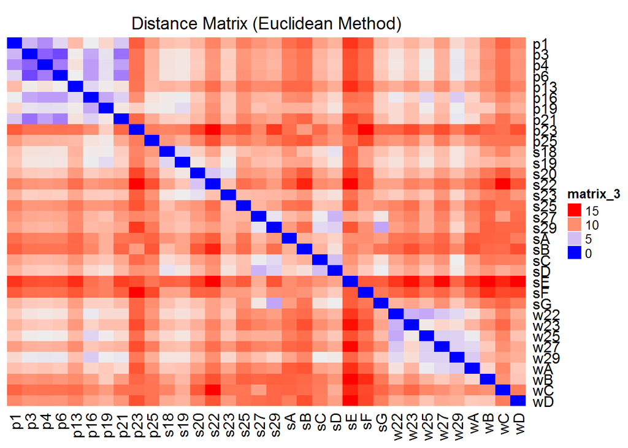

```r
mat <- matDistEU

ht <- Heatmap(
    as.matrix(mat),
    column_title = "Distance Matrix (Euclidean Method)",
    cluster_rows=F, cluster_columns=F)
draw(ht)
```

Calculate Silhouette Score to determine number of clusters

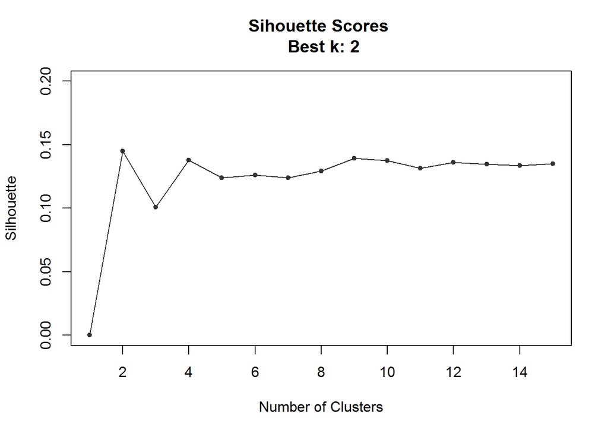

```r
# distance matrix
mat <- matDistEU
numSil <- numeric(15)

# calculate Silhouette scores
for (k in 2:15){
    # average of Silhouette scores
    numSil[k] <- pam(mat, k)$silinfo$avg.width
} # end inner for loop

# find the best number of k
kbest <- which.max(numSil)

# plot the Silhouette scores of each k
plot(numSil, type='l',
     xlab="Number of Clusters",
     ylab="Silhouette",
     main=
         paste("Sihouette Scores", "\n",
               "Best k:", kbest),
     ylim=c(0, 0.2),
     col="grey20")
points(numSil, pch=20, cex=1, col="grey20")
```

Cluster the data

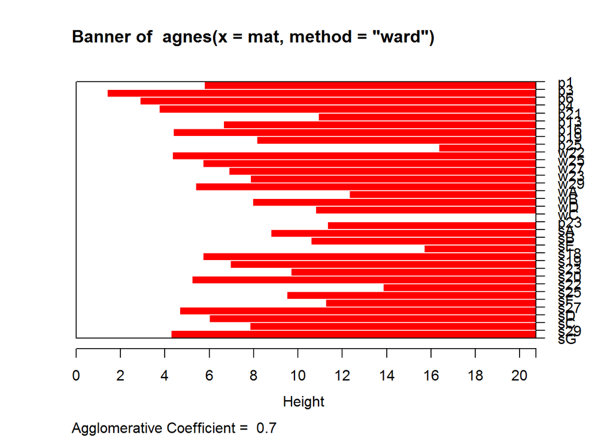

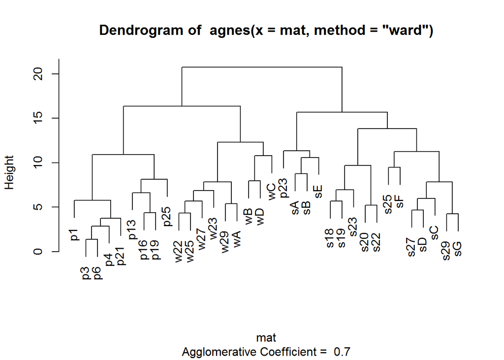

```r
# cluster
mat <- matDistEU
hc_ward <- agnes(mat, method='ward')

# plot the tree
plot(hc_ward)
```

cut the tree

```r
hc <- as.dendrogram(hc_ward)
numClustk2 <- cutree(hc, k=2)
numClustk3 <- cutree(hc, k=3)
```

**plot the result**

```r
dat <- datCPOD$CompDmtScale
dend  <- as.dendrogram(hc_ward)
```

k = 2

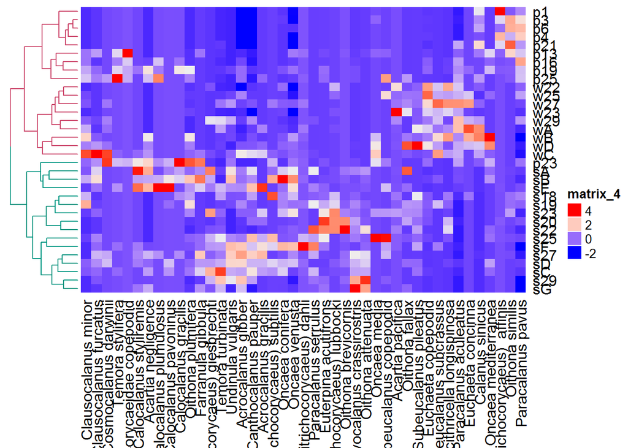

```r
Heatmap(dat,
        row_dend_width = unit(20, "mm"),
        cluster_rows = color_branches(dend, k=2),
        cluster_columns=T,
        show_column_dend=F)
```

k = 3

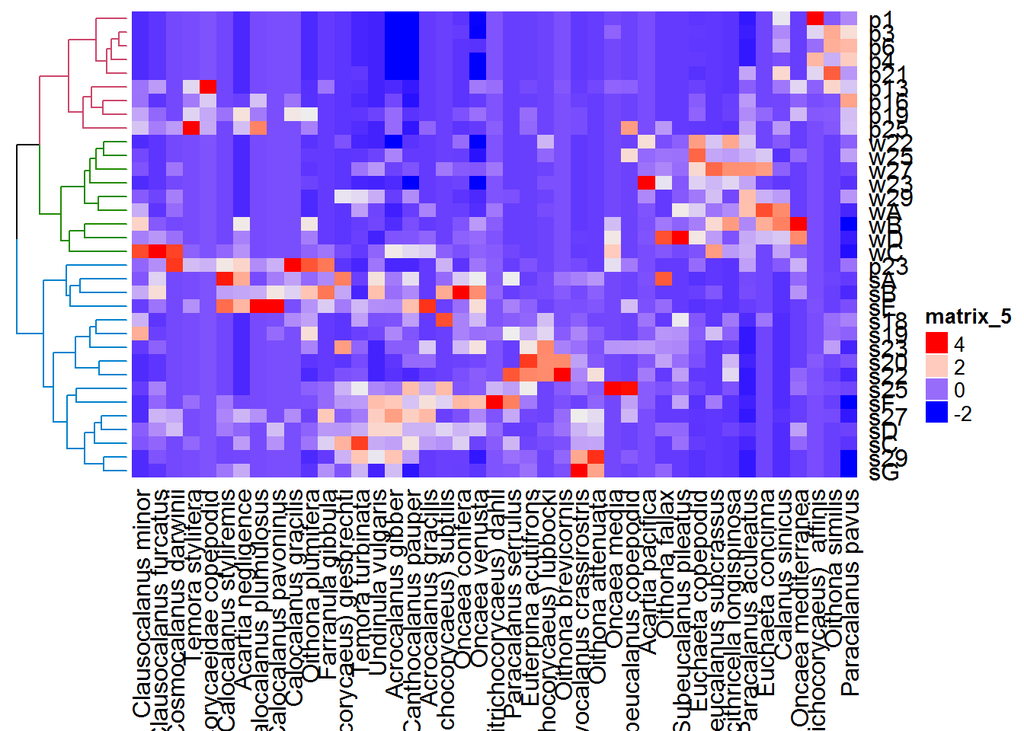

```r
Heatmap(dat,
        row_dend_width = unit(20, "mm"),
        cluster_rows = color_branches(dend, k=3),
        cluster_columns=T,
        show_column_dend=F)
```

plot non-metric multidimensional scaling *Note:* - The code is from the R Documentation of function mrpp{vegan} - http://cc.oulu.fi/~jarioksa/softhelp/vegan/html/mrpp.html - Since there is negative value in scaled data, here I use unscaled data

```r
# NDMS calculation
dat <- datCPOD$CompDmt
resNMDS <- metaMDS(dat)
```

```
## Square root transformation
## Wisconsin double standardization
## *** Solution reached
```

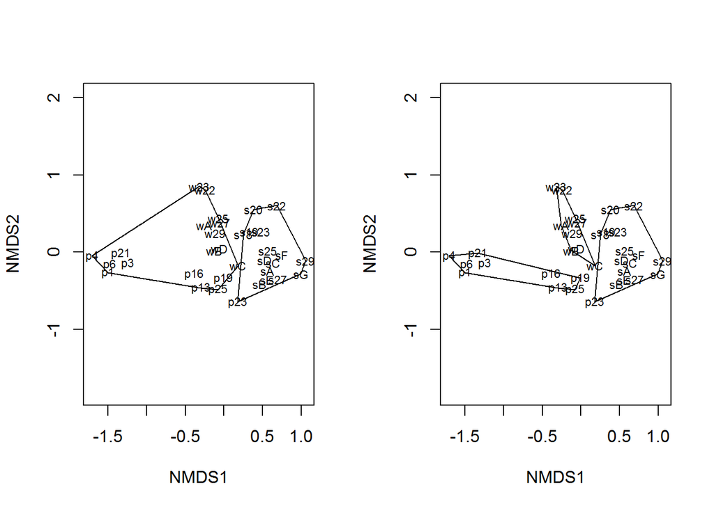

```r
# set plot
par(mfrow=c(1,2))

# plot NDMS plot w/ k = 2
plot(resNMDS, type="text", display="sites")
ordihull(resNMDS, numClustk2)

# plot NDMS plot w/ k = 3
plot(resNMDS, type="text", display="sites" )
ordihull(resNMDS, numClustk3)
```

```r
# set plot
par(mfrow=c(1,1))
```

# Group Differences

Perform MRPP

```r
dat <- datCPOD$CompDmtScale
resMrpp <- mrpp(
    #dat: rows are samples and columns are response variable(s)
    dat,
    #grouping: Factor or numeric index for grouping observations.
    grouping=numClustk2)
```

plot MRPP

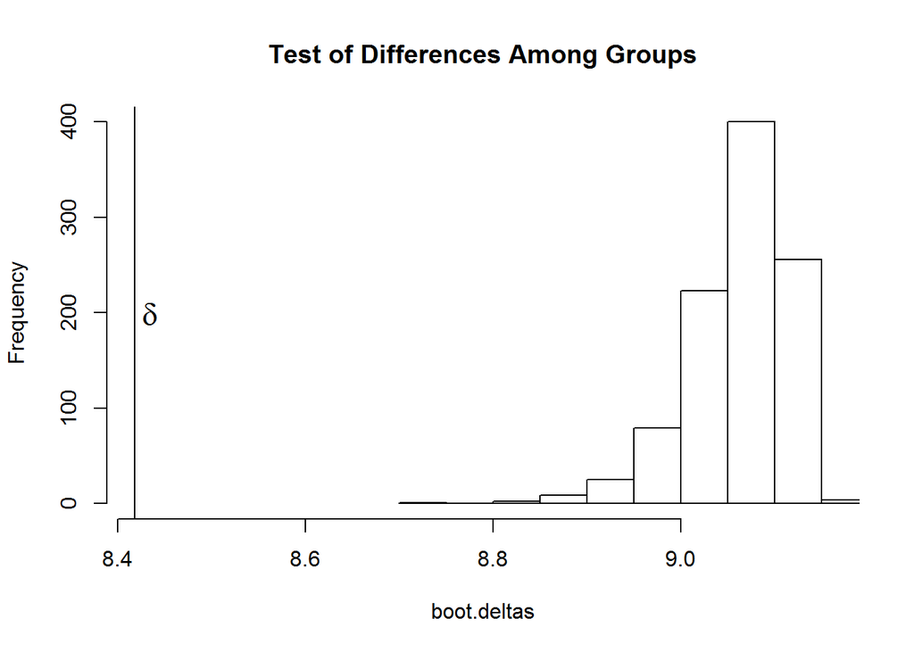

```r
with(resMrpp, {
  fig.dist <- hist(boot.deltas, xlim=range(c(delta,boot.deltas)),
                 main="Test of Differences Among Groups")
  abline(v=delta);
  text(delta, 2*mean(fig.dist$counts), adj = -0.5,
     expression(bold(delta)), cex=1.5 )  }
)
```

Show results

```r
print(resMrpp)
```

```
##
## Call:
## mrpp(dat = dat, grouping = numClustk2)
##
## Dissimilarity index: euclidean
## Weights for groups:  n
##
## Class means and counts:
##
##       1     2
## delta 7.765 9.152
## n     18    16
##
## Chance corrected within-group agreement A: 0.0712
## Based on observed delta 8.418 and expected delta 9.063
##
## Significance of delta: 0.001
## Permutation: free
## Number of permutations: 999
```

# Linear Discriminant Analysis (LDA)

Q2. Use one of the results from the cluster analysis of your previous homework to perform discriminant analysis (DA). Describe 1) whether your data meet the requirement for doing DA, and, 2) if so, which species are most distinct among the clusters.

drop collinear variables

```r
dat <- datCPOD$CompDmtScale
#go through each variable and drop variables with small F values
#as.dist(cor(dat))   #check for multicollinearity
#summary(aov(dat~as.factor(numClustk3)))

#check linearity among variables
#pairs(y[3:8])
#par(mar=c(1,1,1,1))
#pairs(dat)
```

Store results in two list (k=2 & k=3)

```r
# initialization
lstK2 <- list()
lstK3 <- list()

# store the cluster groups
lstK2$NumClust <- numClustk2
lstK3$NumClust <- numClustk3
```

perform LDA

```r
# here I test for k=2 and k=3
lstK2$LDA <- lda(dat, grouping=numClustk2)
lstK3$LDA <- lda(dat, grouping=numClustk3)
# acquire SVD decomposition of LDA result
# (svd^2 gives eigenvalues)
lstK2$SVD <- lstK2$LDA$svd
lstK3$SVD <- lstK3$LDA$svd

# relative magnitude of eigenvalue
lstK2$RelEig <- lstK2$SVD^2 / sum(lstK2$SVD^2)
lstK3$RelEig <- lstK3$SVD^2 / sum(lstK3$SVD^2)
```

classification based on DA

```r
lstK2$Pred = predict(lstK2$LDA)
lstK3$Pred = predict(lstK3$LDA)

lstK2$Scores = lstK2$Pred$x
lstK3$Scores = lstK3$Pred$x
```

visually inspect group difference in canonical scores

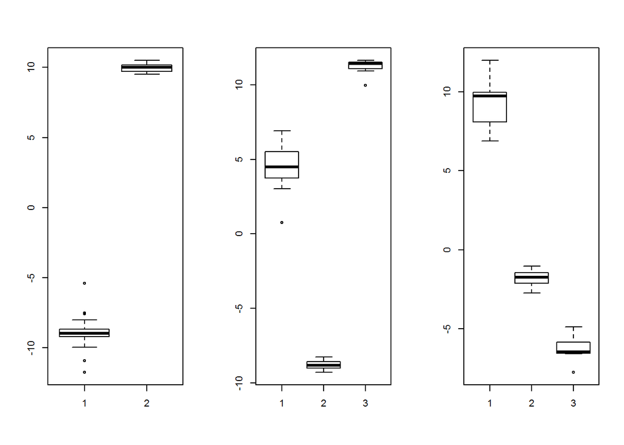

```r
# set plot
par(mfrow=c(1,3))

# boxplot
res = data.frame(
    Group=lstK2$NumClust,
    LD1=lstK2$Scores)
boxplot(LD1~Group, data = res)
#range(res$LD1)
#boxplot(LD1~Group, data = res, ylim=c(-12, 12),
#        notch=TRUE,varwidth=TRUE)

# boxplot
res = data.frame(
    Group=lstK3$NumClust,
    LD1=lstK3$Scores)
boxplot(LD1.LD1~Group, data=res)
boxplot(LD1.LD2~Group, data=res)
```

```r
# reset plot
par(mfrow=c(1,1))
```

classification table

```r
# classification table
lstK2$Table = table(
    lstK2$NumClust,
    lstK2$Pred$class)

# correct classification rate
lstK2$ClassRate <- sum(diag(lstK2$Table))/sum(lstK2$Table)

# classification table
lstK3$Table = table(
    lstK3$NumClust,
    lstK3$Pred$class)

# correct classification rate
lstK3$ClassRate <- sum(diag(lstK3$Table))/sum(lstK3$Table)

# print the result
print(lstK2$Table)
```

```
##
##      1  2
##   1 18  0
##   2  0 16
```

```r
print(lstK3$Table)
```

```
##
##      1  2  3
##   1  9  0  0
##   2  0 16  0
##   3  0  0  9
```

```r
print(lstK2$ClassRate)
```

```
## [1] 1
```

```r
print(lstK3$ClassRate)
```

```
## [1] 1
```

# Classifcation And Regression Tree

3. Use the “dominant” copepod species data (from HW1).  
   Perform CART of stations based on percent composition data of the dominant species, and tell your story about these copepod data. You can use also the environmental data if you wish.

You are allowed to use whatever built-in functions in Matlab or R, such as classregtree.m.

package for CART

```r
library(rpart)
dat = datCPOD$CompDmtScale

# K=2
res = rpart(
    lstK2$NumClust~dat,
    method='class',
    parms=list(split='gini'))
lstK2$Tree1 <- res

res = rpart(
    lstK2$NumClust~dat,
    method='class',
    parms=list(
        prior=c(0.5, 0.5),
        split='gini'))  #specify prior
lstK2$Tree2 <- res
##############################################
# K=3
res = rpart(
    lstK3$NumClust~dat,
    method='class',
    parms=list(split='gini'))
lstK3$Tree1 <- res

res = rpart(
    lstK3$NumClust~dat,
    method='class',
    parms=list(
        prior=c(0.33, 0.33, 0.34),
        split='gini'))  #specify prior
lstK3$Tree2 <- res
```

plot the results (k=2)

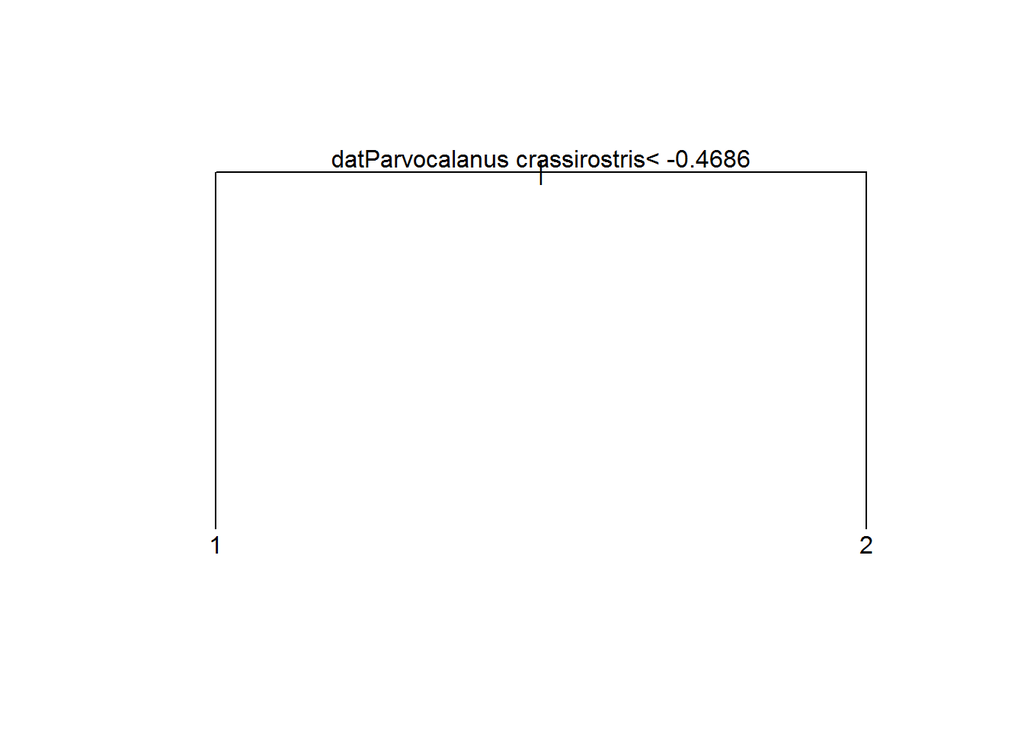

```r
res <- lstK2$Tree1
grp <- lstK2$NumClust

# plot the tree
plot(res,margin=0.1)
text(res)
```

```r
# print the residulas
print(
    1-sum(residuals(res)^2)/
        sum((grp-mean(grp,na.rm=T))^2,
    na.rm=T))
```

```
## [1] 0.7638889
```

plot the results (k=3)

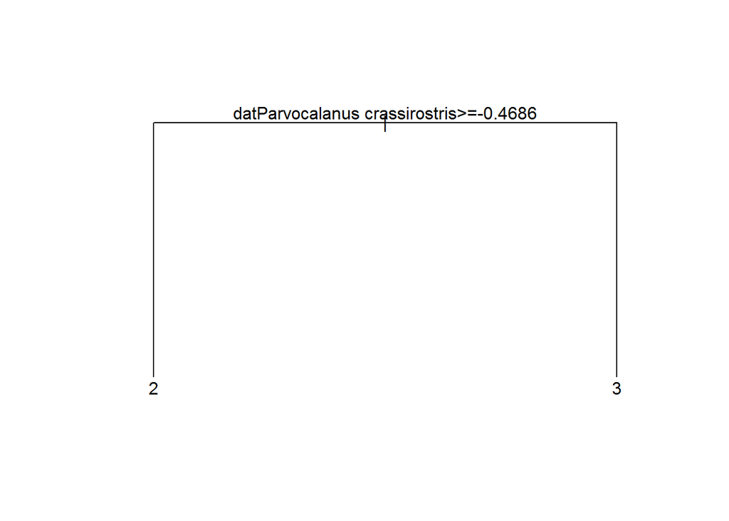

```r
res <- lstK3$Tree1
grp <- lstK3$NumClust

# plot the tree
plot(res,margin=0.1)
text(res)
```

```r
# print the residulas
print(
    1-sum(residuals(res)^2)/
        sum((grp-mean(grp,na.rm=T))^2,
    na.rm=T))
```

```
## [1] 0.5
```